# Practicum2_Part1_Group4

## ##Part3##

#chart1: From this chart, we can see that 7 articles are in only print model.And 12 articles are in print-electronic model. So we could tell that electronic-print version is the new trend of published articles.

```r
library(ggplot2)
result <- dbSendQuery(dbcon,"SELECT aPubModel, count(DISTINCT ar_ID) AS count
                     FROM Summary_facts
                     GROUP BY aPubModel;")
chart1 = fetch(result, n=-1)
dfchart1 <- data.frame(col1=c(chart1[,1]),col2=c(chart1[,2]))
dfchart1
```

| col1 | col2 |
| --- | --- |
| Print | 7 |
| Print-Electronic | 12 |

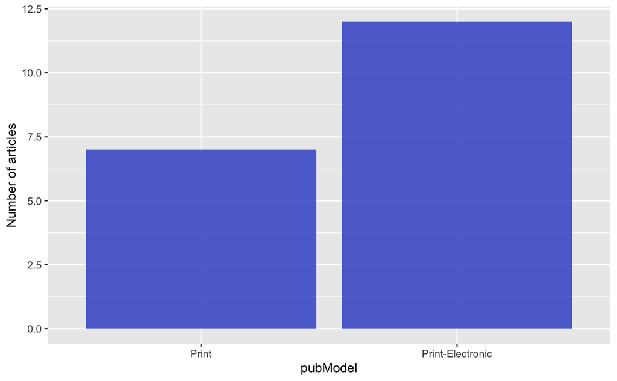

```r
ggplot(data = dfchart1,
      mapping=aes(x=col1, y=col2))+
      geom_bar(stat = "identity", fill=rgb(0.2,0.3,0.8,0.8))+
      xlab("pubModel") +
      ylab("Number of articles")
```

#chart2: From this chart, we can see that purblications show a seasonal pattern by author

#we can see that quarter1 has then most authors publish articles

```r
sql2 <- dbSendQuery(dbcon,"SELECT Year, Quarter, count(distinct au_ID) as numberOfAuthor
                      FROM Summary_facts
                      GROUP BY Year, Quarter;")
chart2 = fetch(sql2, n=-1)
dfchart2 <- data.frame(col1=c(chart2[,1]),col2=c(chart2[,2]),col3=c(chart2[,3]))
dfchart2
```

| col1 | col2 | col3 |
| --- | --- | --- |
| 2012 | Q1 | 32 |
| 2012 | Q2 | 28 |
| 2012 | Q3 | 19 |
| 2012 | Q4 | 22 |
| 2013 | Q1 | 17 |

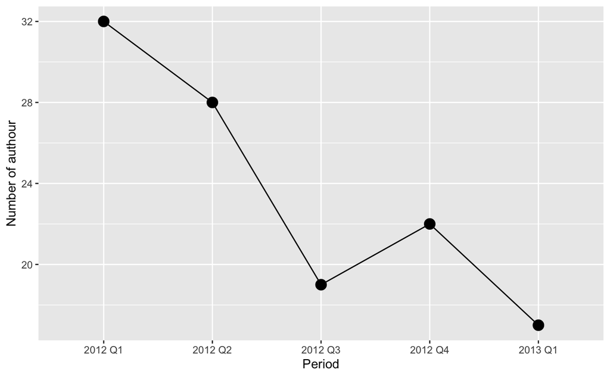

```r
dfchart2$period <- paste(dfchart2$col1, dfchart2$col2)
ggplot(data = dfchart2, mapping = aes(x=period, y=col3,group=1)) +
       geom_line() +
       geom_point(size=4) +
       xlab("Period") +
       ylab("Number of authour")
```

#chart3: From this chart, we can see that publication show a seasonal pattern by journal

#we can see that quarter1 has then most published journals

```r
sql3 <- dbSendQuery(dbcon,"SELECT Year, Quarter, count(distinct j_ID) as count_by_journal
                      FROM Summary_facts
                      GROUP BY Year, Quarter;")
chart3 = fetch(sql3, n=-1)
dfchart3 <- data.frame(col1=c(chart3[,1]),col2=c(chart3[,2]),col3=c(chart3[,3]))
dfchart3
```

| col1 | col2 | col3 |
| --- | --- | --- |
| 2012 | Q1 | 5 |
| 2012 | Q2 | 4 |
| 2012 | Q3 | 4 |
| 2012 | Q4 | 3 |
| 2013 | Q1 | 3 |

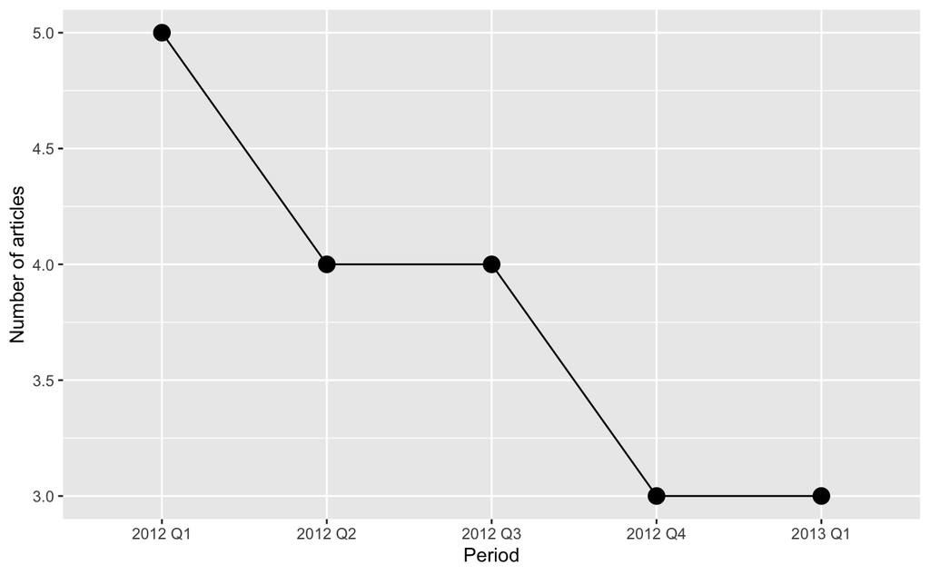

```r
dfchart3$period <- paste(dfchart3$col1, dfchart3$col2)
ggplot(data = dfchart3, mapping = aes(x=period, y=col3,group=1)) +
       geom_line() +
       geom_point(size = 4) +
       xlab("Period") +
       ylab("Number of articles")
```

#chart4: From this chart, we can see that published articles show a seasonal pattern when we retrieved data from History_dim and showed the number of article published every quarter.

#The reason why we get this query is because in Journal_dim, we can only see data until 2013 Q1, to check the seasnal pattern in a different way, we decide to get data from History_dim in which pubStatus is ‘pubmed’.

#We can see that the fourth quarter has the largest number of published articles from history.

#I think the difference is because ‘pubmed’ date in History_dim is a little bit before real published date, so plenty of articles were pubmeded in Q4 but got really published in Journal in Q1 next year.

```r
sql4 <- dbSendQuery(dbcon,"SELECT hQuarter, count(distinct h_ID) AS numberOfArticle
FROM Summary_history
Where hPubStatus = 'pubmed'
GROUP BY hQuarter;")
chart4 = fetch(sql4, n=-1)
dfchart4 <- data.frame(col1=c(chart4[,1]),col2=c(chart4[,2]))
dfchart4
```

| col1 | col2 |
| --- | --- |
| Q1 | 5 |
| Q2 | 2 |
| Q3 | 4 |
| Q4 | 8 |

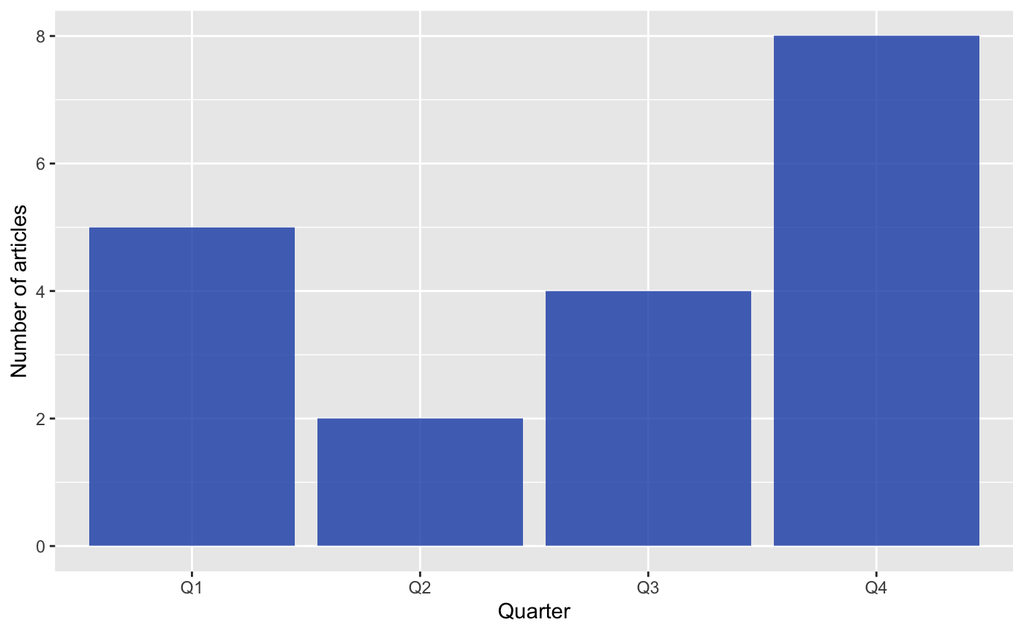

```r
dfchart4$period <- paste(dfchart4$col1, dfchart4$col2)
ggplot(data = dfchart4,
      mapping=aes(x=col1, y=col2))+
      geom_bar(stat = "identity", fill=rgb(0.1,0.3,0.7,0.8))+
      xlab("Quarter") +
      ylab("Number of articles")
```

```r
dbDisconnect(dbcon)
```